============ title: Explore NEON LiDAR Data author: Allie Weill date: June 12, 2016 output: html_document ============= ### Bio

Hi all! I am a 4th year PhD student in the Ecology Graduate Group at UC Davis. My research focuses on fire ecology of the shrublands (chaparral) of California. I’m interested in how these fire-prone and fire-adapted systems respond to the changes in fire frequency and magnitude that result from climate change and human activity. My work involves both plants (populations and communities) and people who live in fire-prone systems.

I am also involved in a citizen science project focused on phenology at a local reserve. The entire reserve burned in 2015, which has provided an opportunity for our citizen scientists to gather data that may help us understand the relationship between phenology and post-fire regeneration.

For more info about me and my research, check out my website [here](http://wwww.amweill.weebly.com). I am also active on twitter. [Follow me here!](https://twitter.com/Al_R_Wallace)

### Course Goals

My main goal is to learn to use remotely sensed data in order to look at vegetation regrowth following fire in order to see how regrowth varies with climate and other factors. I am also interested in learning to use remote sensing data to analyze other questions related to fire.

### Capstone Project Idea #1

**Question: How do climate variables affect post-fire regeneration of Western shrublands?**

**Background:** Climate change is expected to shape fire regimes and fire-prone ecosystems in a variety of ways. A recent paper found that a warmer climate enhances post-fire regeneration in South African shrublands (fynbos). I want to see whether other systems work the same way.

**Data needed:** hyperspectral data, LiDAR (?), forest structure, temp, precip, fire perimeters. Region TBD–ordinarily I would use California data but none appears to be available from NEON yet.

### Capstone Idea #2

**Question: Is there a relationship between phenology and fire? How does fire affect timing of flowering and leafing out post-fire?**

**Data needed:** phenology data, hyperspectral data (for fire severity and size?), fire perimeters.

### Week 3 Activity

This activity demonstrates using some of the NEON Teakettle LiDAR products in R.

```r
   library(rgdal)
   library(raster)

   # set working directory to ensure R can find the file we wish to import
   setwd("~/Documents/data/NEONDI-2016/")
```

This section loads and plots 2 different raster files. (NOTE: file has not been loading when knit only! Can’t figure out what is going wrong–the file is found when run in the console. First, the DSM.

```r
   # import dsm for Teakettle
   teak_dsm <- raster("NEONdata/D17-California/TEAK/2013/lidar/TEAK_lidarDSM.tif")
```

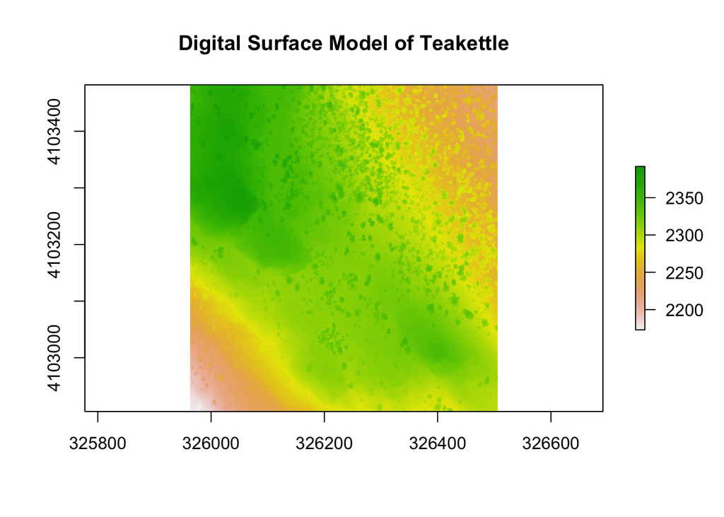

```r
  #plot dsm
  plot(teak_dsm, main="Digital Surface Model of Teakettle")
```

Next, we’ll try the CHM.

```r
   # import chmfor Teakettle
   teak_chm <- raster("NEONdata/D17-California/TEAK/2013/lidar/TEAK_lidarCHM.tif")
```

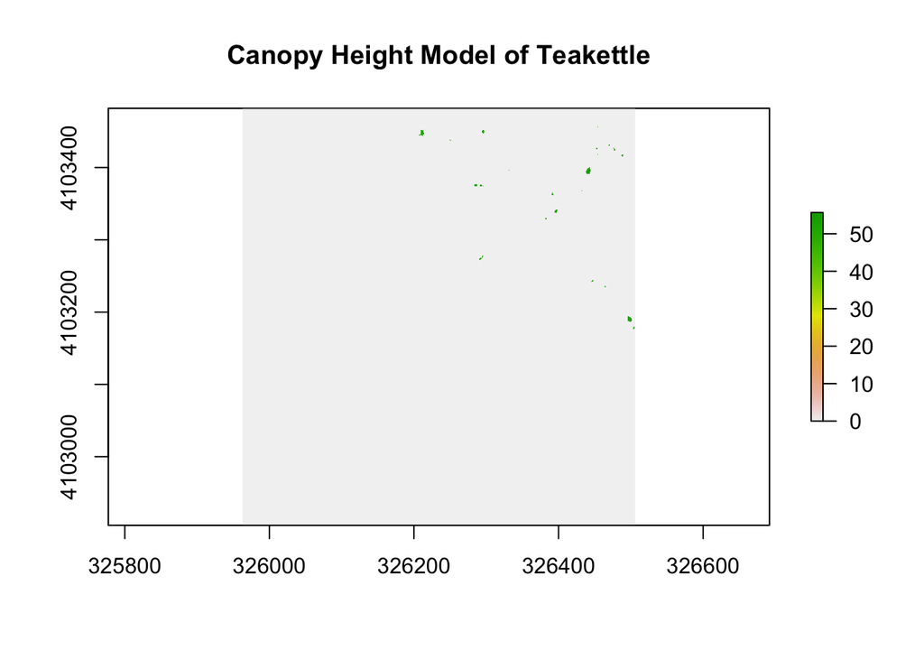

```r
  #plot chm
  plot(teak_chm, main="Canopy Height Model of Teakettle")
```

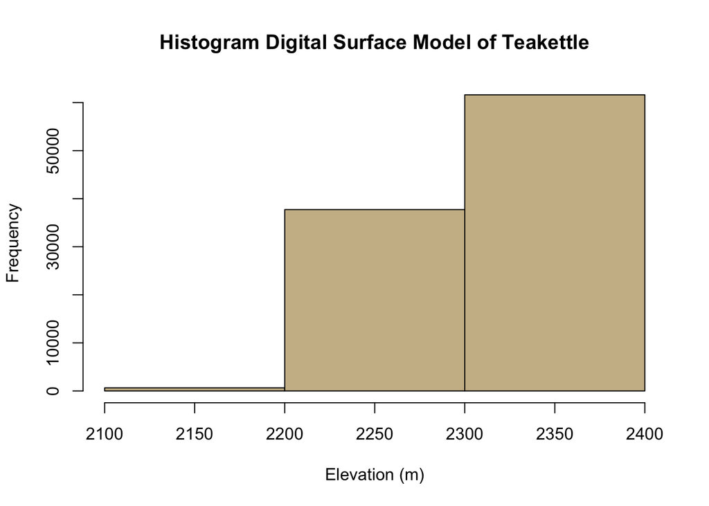

```r
  #histogram of dsm
# Plot distribution of raster values
DSMhist <- hist(teak_dsm,
     breaks=3,
     main="Histogram Digital Surface Model of Teakettle",
     col="wheat3",  # changes bin color
     xlab= "Elevation (m)")  # label the x-axis
```

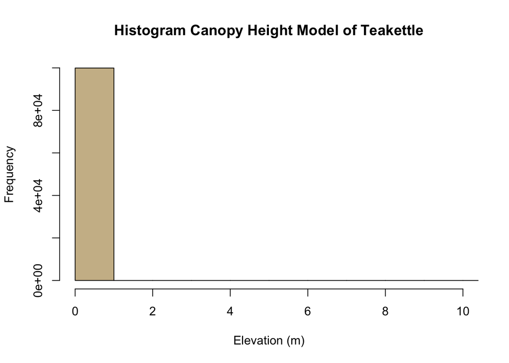

```r
  #histogram of dsm
# Plot distribution of raster values
DSMhist <- hist(teak_chm,
     breaks=50,
     xlim=c(0,10),
     main="Histogram Canopy Height Model of Teakettle",
     col="wheat3",  # changes bin color
     xlab= "Elevation (m)")  # label the x-axis
```